# Temporary Unemployed to Employed

Linked CPS Follow-Up for Temporary Layoffs vs Permanent Job Losers

Published

March 28, 2026

## Overview

This note asks a simple panel-style question using linked monthly CPS records: when someone reports being unemployed because of a **temporary layoff**, how often do they later show up as **employed** in subsequent CPS interviews, and how has that changed over time?

The comparison group is **permanent job losers**. The report tracks three linked outcomes by the respondent’s **origin month**:

1. employed in the **next observed interview**
2. employed **within the next 3 observed interviews**
3. employed at the respondent’s **first reappearance after the long CPS rotation gap**

All three are shown **over time**, with temporary layoffs and permanent job losers plotted together.

## Rotation Design

The CPS is not a clean 16-month monthly panel. It uses a **4-8-4 rotation**:

- interviewed for 4 consecutive months
- out of sample for 8 months
- interviewed for 4 consecutive months again

So this report does **not** measure “employed within the next 6 calendar months” for everyone. Instead it measures employment at later **observed CPS interviews**. For linkage, the report uses the validated person identifier `CPSIDV`.

```r
library(tidyverse)
library(ipumsr)
library(lubridate)
library(gt)
library(scales)

theme_report <- theme_minimal(base_size = 11, base_family = "sans") +
  theme(
    plot.title = element_text(face = "bold", size = 13),
    plot.subtitle = element_text(color = "grey50", size = 9),
    plot.caption = element_text(color = "grey60", size = 7, hjust = 0),
    panel.grid.minor = element_blank(),
    panel.grid.major.x = element_blank(),
    axis.title = element_text(size = 9, color = "grey40"),
    axis.text = element_text(size = 8, color = "grey50"),
    legend.position = "top",
    legend.text = element_text(size = 8),
    legend.title = element_blank()
  )

theme_set(theme_report)

analysis_dir <- file.path("data", "CPS", "temporary_to_employed")
dir.create(analysis_dir, recursive = TRUE, showWarnings = FALSE)

extract_ddi_path <- file.path(analysis_dir, "cps_temp_to_employed.xml")
extract_csv_path <- file.path(analysis_dir, "cps_temp_to_employed.csv.gz")
monthly_transition_path <- file.path(analysis_dir, "monthly_transition_rates.csv")
origin_record_path <- file.path(analysis_dir, "origin_records_with_followup.csv.gz")
```

## Extract Definition

```r
extract_description <- paste(
  "Temporary to employed monthly CPS extract:",
  "CPSIDV/CPSIDP, EMPSTAT, WHYUNEMP, WTFINL, AGE, 1994-present"
)

ensure_temp_to_employed_extract <- function(target_ddi, target_csv, extract_desc) {
  if (file.exists(target_ddi) && file.exists(target_csv)) {
    return(list(ddi = target_ddi, csv = target_csv, source = "local"))
  }

  all_samples <- get_sample_info("cps")

  ipums_samples <- all_samples |>
    filter(
      grepl("^cps\\d{4}_\\d{2}[bs]$", name),
      as.numeric(gsub("cps(\\d{4}).*", "\\1", name)) >= 1994,
      !str_detect(.data$description, "ASEC")
    ) |>
    pull(name)

  extract_def <- define_extract_micro(
    collection = "cps",
    description = extract_desc,
    samples = ipums_samples,
    variables = list(
      "YEAR", "MONTH", "PERNUM", "WTFINL",
      "CPSIDP", "CPSIDV",
      "AGE", "EMPSTAT", "WHYUNEMP"
    ),
    data_format = "csv"
  )

  extract_history <- tryCatch(
    get_extract_history("cps", how_many = 10),
    error = function(e) NULL
  )

  downloadable <- NULL
  if (!is.null(extract_history)) {
    matching_completed <- keep(
      extract_history,
      \(x) identical(x$description, extract_desc) && identical(x$status, "completed")
    )

    if (length(matching_completed) > 0) {
      downloadable <- matching_completed[[1]]
    }
  }

  if (is.null(downloadable)) {
    submitted <- submit_extract(extract_def)
    downloadable <- wait_for_extract(submitted)
  }

  partial_xml <- list.files(analysis_dir, pattern = "^cps_\\d+\\.xml$", full.names = TRUE)
  partial_csv <- list.files(analysis_dir, pattern = "^cps_\\d+\\.csv\\.gz$", full.names = TRUE)

  if (length(c(partial_xml, partial_csv)) > 0) {
    file.remove(c(partial_xml, partial_csv))
  }

  path_to_ddi <- NULL
  for (attempt in 1:5) {
    path_to_ddi <- tryCatch(
      download_extract(downloadable, download_dir = analysis_dir),
      error = function(e) {
        if (attempt < 5) {
          Sys.sleep(attempt * 10)
        }
        NULL
      }
    )

    if (!is.null(path_to_ddi)) {
      break
    }
  }

  if (is.null(path_to_ddi)) {
    stop("Failed to download the temporary-to-employed CPS extract.")
  }

  downloaded_csv <- sub("\\.xml$", ".csv.gz", path_to_ddi)

  if (file.exists(target_ddi)) file.remove(target_ddi)
  if (file.exists(target_csv)) file.remove(target_csv)

  ok_ddi <- file.copy(path_to_ddi, target_ddi)
  ok_csv <- file.copy(downloaded_csv, target_csv)

  if (!ok_ddi || !ok_csv) {
    stop("Failed to copy downloaded CPS extract into the analysis directory.")
  }

  file.remove(path_to_ddi)
  file.remove(downloaded_csv)

  list(ddi = target_ddi, csv = target_csv, source = "downloaded")
}

extract_files <- ensure_temp_to_employed_extract(
  extract_ddi_path,
  extract_csv_path,
  extract_description
)

ddi <- read_ipums_ddi(extract_files$ddi)
cps_raw <- read_ipums_micro(ddi, data_file = extract_files$csv, verbose = FALSE)
```

```r
tibble(
  Item = c(
    "Source",
    "Rows",
    "Years",
    "Months",
    "Variables"
  ),
  Value = c(
    extract_files$source,
    comma(nrow(cps_raw)),
    paste0(min(cps_raw$YEAR, na.rm = TRUE), "-", max(cps_raw$YEAR, na.rm = TRUE)),
    n_distinct(paste(cps_raw$YEAR, cps_raw$MONTH)),
    paste(names(cps_raw), collapse = ", ")
  )
) |>
  gt() |>
  tab_options(
    table.font.size = px(11),
    column_labels.font.weight = "bold",
    column_labels.background.color = "#2c3e50"
  ) |>
  tab_style(
    style = cell_text(color = "white"),
    locations = cells_column_labels()
  )
```

Linked CPS extract used for the temporary-to-employed analysis.

| Item | Value |
| --- | --- |
| Source | local |
| Rows | 2,566,995 |
| Years | 1994-1995 |
| Months | 19 |
| Variables | YEAR, SERIAL, MONTH, HWTFINL, CPSID, ASECFLAG, PERNUM, WTFINL, CPSIDP, CPSIDV, AGE, EMPSTAT, WHYUNEMP |

## Link Construction

```r
month_index <- function(year, month) {
  as.integer(year) * 12L + as.integer(month)
}

cps_all <- cps_raw |>
  transmute(
    year = as.integer(YEAR),
    month = as.integer(MONTH),
    date = as.Date(sprintf("%04d-%02d-01", year, month)),
    ym = month_index(year, month),
    weight = as.numeric(WTFINL),
    age = as.numeric(AGE),
    empstat = as.integer(EMPSTAT),
    whyunemp = as.integer(WHYUNEMP),
    link_id = as.character(CPSIDV)
  ) |>
  filter(age >= 16) |>
  mutate(
    link_id = na_if(link_id, "0"),
    unemployed_reason = case_when(
      whyunemp == 1L ~ "Temporary Layoff",
      whyunemp == 2L ~ "Permanent Job Loser",
      TRUE ~ NA_character_
    ),
    is_employed = empstat %in% c(10L, 12L)
  )

origin_all <- cps_all |>
  filter(whyunemp %in% c(1L, 2L))

origin_linkable_ids <- origin_all |>
  filter(!is.na(link_id)) |>
  distinct(link_id)

linked_panel <- cps_all |>
  semi_join(origin_linkable_ids, by = "link_id") |>
  arrange(link_id, ym, date) |>
  distinct(link_id, ym, .keep_all = TRUE) |>
  group_by(link_id) |>
  mutate(
    lead_ym_1 = lead(ym, 1),
    lead_ym_2 = lead(ym, 2),
    lead_ym_3 = lead(ym, 3),
    lead_ym_4 = lead(ym, 4),
    lead_ym_5 = lead(ym, 5),
    lead_ym_6 = lead(ym, 6),
    lead_ym_7 = lead(ym, 7),
    lead_emp_1 = lead(is_employed, 1),
    lead_emp_2 = lead(is_employed, 2),
    lead_emp_3 = lead(is_employed, 3),
    lead_emp_4 = lead(is_employed, 4),
    lead_emp_5 = lead(is_employed, 5),
    lead_emp_6 = lead(is_employed, 6),
    lead_emp_7 = lead(is_employed, 7)
  ) |>
  ungroup()

origin_records <- linked_panel |>
  filter(whyunemp %in% c(1L, 2L)) |>
  rowwise() |>
  mutate(
    employed_next_observed = if (is.na(lead_emp_1)) NA else lead_emp_1,
    employed_within_next3 = {
      vals <- c(lead_emp_1, lead_emp_2, lead_emp_3)
      if (all(is.na(vals))) NA else any(vals, na.rm = TRUE)
    },
    employed_after_gap = {
      gap_vals <- c(
        lead_ym_1 - ym,
        lead_ym_2 - ym,
        lead_ym_3 - ym,
        lead_ym_4 - ym,
        lead_ym_5 - ym,
        lead_ym_6 - ym,
        lead_ym_7 - ym
      )
      emp_vals <- c(
        lead_emp_1, lead_emp_2, lead_emp_3, lead_emp_4,
        lead_emp_5, lead_emp_6, lead_emp_7
      )
      idx <- which(!is.na(gap_vals) & gap_vals >= 9L)[1]
      if (length(idx) == 0 || is.na(idx)) NA else emp_vals[idx]
    }
  ) |>
  ungroup() |>
  select(
    date, year, month, weight, unemployed_reason,
    employed_next_observed, employed_within_next3, employed_after_gap
  )

monthly_transition_rates <- origin_records |>
  group_by(date, unemployed_reason) |>
  summarise(
    origin_weight = sum(weight, na.rm = TRUE),
    origin_n = n(),
    next_obs_followup_share = sum(weight[!is.na(employed_next_observed)], na.rm = TRUE) / sum(weight, na.rm = TRUE),
    next_obs_employed_share = weighted.mean(employed_next_observed, weight, na.rm = TRUE),
    next3_followup_share = sum(weight[!is.na(employed_within_next3)], na.rm = TRUE) / sum(weight, na.rm = TRUE),
    next3_employed_share = weighted.mean(employed_within_next3, weight, na.rm = TRUE),
    gap_followup_share = sum(weight[!is.na(employed_after_gap)], na.rm = TRUE) / sum(weight, na.rm = TRUE),
    gap_employed_share = weighted.mean(employed_after_gap, weight, na.rm = TRUE),
    .groups = "drop"
  )

write_csv(monthly_transition_rates, monthly_transition_path)
write_csv(origin_records, origin_record_path)
```

## Linkage Coverage

```r
linkage_summary <- origin_all |>
  mutate(linkable = !is.na(link_id)) |>
  group_by(reason = unemployed_reason) |>
  summarise(
    Observations = n(),
    `Weighted Linkable Share` = weighted.mean(linkable, weight, na.rm = TRUE),
    .groups = "drop"
  )

linkage_summary |>
  gt() |>
  fmt_number(columns = Observations, decimals = 0) |>
  fmt_percent(columns = `Weighted Linkable Share`, decimals = 1) |>
  tab_options(
    table.font.size = px(11),
    column_labels.font.weight = "bold",
    column_labels.background.color = "#2c3e50"
  ) |>
  tab_style(
    style = cell_text(color = "white"),
    locations = cells_column_labels()
  )
```

Origin-cohort linkage coverage for temporary layoffs and permanent job losers.

| reason | Observations | Weighted Linkable Share |
| --- | --- | --- |
| Permanent Job Loser | 18,298 | 100.0% |
| Temporary Layoff | 10,025 | 100.0% |

## Employed in Next Observed Interview

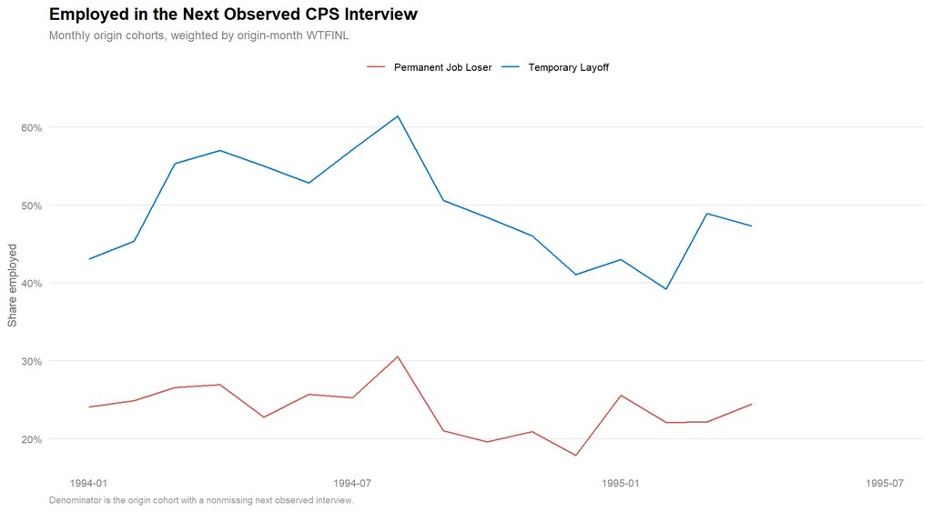

```r
monthly_transition_rates |>
  ggplot(aes(x = date, y = next_obs_employed_share, color = unemployed_reason)) +
  geom_line(linewidth = 0.7, alpha = 0.9) +
  scale_color_manual(
    values = c(
      "Temporary Layoff" = "#0073C2",
      "Permanent Job Loser" = "#CD534C"
    )
  ) +
  scale_y_continuous(labels = percent_format(accuracy = 1)) +
  labs(
    title = "Employed in the Next Observed CPS Interview",
    subtitle = "Monthly origin cohorts, weighted by origin-month WTFINL",
    x = NULL,
    y = "Share employed",
    color = NULL,
    caption = "Denominator is the origin cohort with a nonmissing next observed interview."
  )
```

## Employed Within Next 3 Observed Interviews

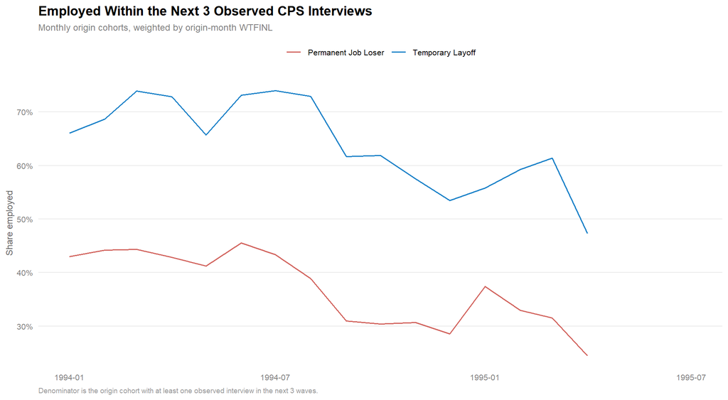

```r
monthly_transition_rates |>
  ggplot(aes(x = date, y = next3_employed_share, color = unemployed_reason)) +
  geom_line(linewidth = 0.7, alpha = 0.9) +
  scale_color_manual(
    values = c(
      "Temporary Layoff" = "#0073C2",
      "Permanent Job Loser" = "#CD534C"
    )
  ) +
  scale_y_continuous(labels = percent_format(accuracy = 1)) +
  labs(
    title = "Employed Within the Next 3 Observed CPS Interviews",
    subtitle = "Monthly origin cohorts, weighted by origin-month WTFINL",
    x = NULL,
    y = "Share employed",
    color = NULL,
    caption = "Denominator is the origin cohort with at least one observed interview in the next 3 waves."
  )
```

## Employed at Reappearance After the Long Gap

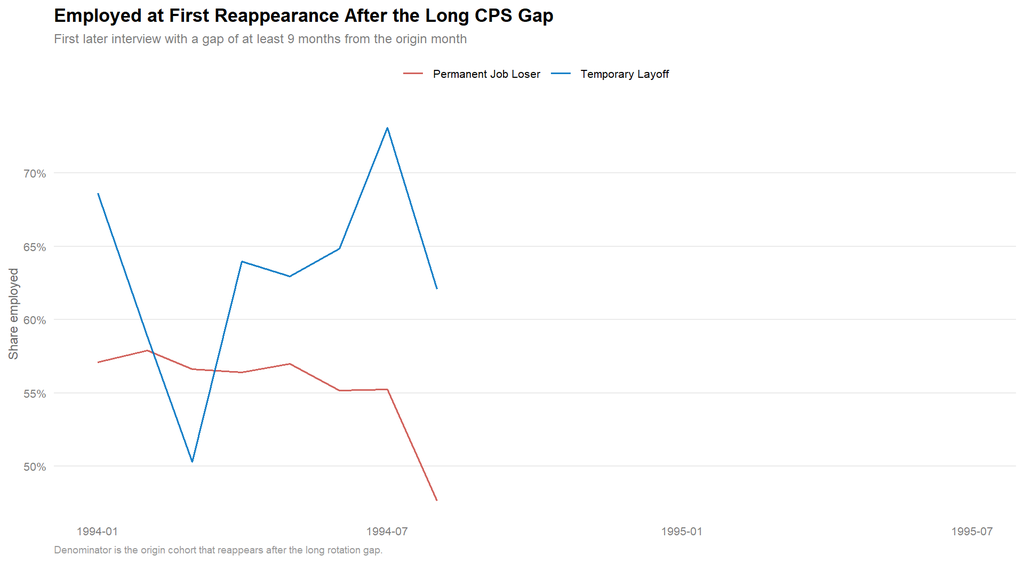

```r
monthly_transition_rates |>
  ggplot(aes(x = date, y = gap_employed_share, color = unemployed_reason)) +
  geom_line(linewidth = 0.7, alpha = 0.9) +
  scale_color_manual(
    values = c(
      "Temporary Layoff" = "#0073C2",
      "Permanent Job Loser" = "#CD534C"
    )
  ) +
  scale_y_continuous(labels = percent_format(accuracy = 1)) +
  labs(
    title = "Employed at First Reappearance After the Long CPS Gap",
    subtitle = "First later interview with a gap of at least 9 months from the origin month",
    x = NULL,
    y = "Share employed",
    color = NULL,
    caption = "Denominator is the origin cohort that reappears after the long rotation gap."
  )
```

## Coverage Over Time

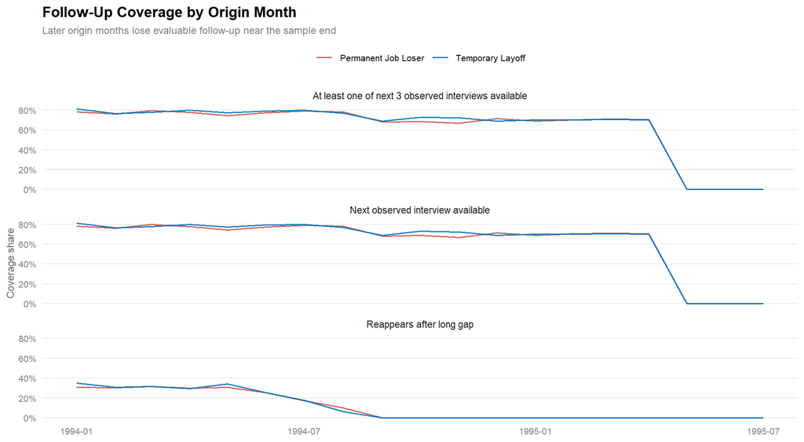

```r
coverage_long <- monthly_transition_rates |>
  select(
    date, unemployed_reason,
    next_obs_followup_share, next3_followup_share, gap_followup_share
  ) |>
  pivot_longer(
    cols = -c(date, unemployed_reason),
    names_to = "metric",
    values_to = "value"
  ) |>
  mutate(
    metric = recode(
      metric,
      next_obs_followup_share = "Next observed interview available",
      next3_followup_share = "At least one of next 3 observed interviews available",
      gap_followup_share = "Reappears after long gap"
    )
  )

coverage_long |>
  ggplot(aes(x = date, y = value, color = unemployed_reason)) +
  geom_line(linewidth = 0.6, alpha = 0.9) +
  facet_wrap(~metric, ncol = 1) +
  scale_color_manual(
    values = c(
      "Temporary Layoff" = "#0073C2",
      "Permanent Job Loser" = "#CD534C"
    )
  ) +
  scale_y_continuous(labels = percent_format(accuracy = 1)) +
  labs(
    title = "Follow-Up Coverage by Origin Month",
    subtitle = "Later origin months lose evaluable follow-up near the sample end",
    x = NULL,
    y = "Coverage share",
    color = NULL
  )
```

## Latest Available Comparison

```r
latest_complete <- monthly_transition_rates |>
  filter(!is.na(next_obs_employed_share), !is.na(next3_employed_share), !is.na(gap_employed_share)) |>
  group_by(unemployed_reason) |>
  filter(date == max(date, na.rm = TRUE)) |>
  ungroup() |>
  transmute(
    Date = date,
    Group = unemployed_reason,
    `Employed next observed interview` = next_obs_employed_share,
    `Employed within next 3 observed interviews` = next3_employed_share,
    `Employed after long-gap reappearance` = gap_employed_share
  )

latest_complete |>
  gt() |>
  fmt_date(columns = Date, date_style = 10) |>
  fmt_percent(
    columns = c(
      `Employed next observed interview`,
      `Employed within next 3 observed interviews`,
      `Employed after long-gap reappearance`
    ),
    decimals = 1
  ) |>
  tab_options(
    table.font.size = px(11),
    column_labels.font.weight = "bold",
    column_labels.background.color = "#2c3e50"
  ) |>
  tab_style(
    style = cell_text(color = "white"),
    locations = cells_column_labels()
  )
```

Latest available monthly origin-cohort transition rates.

| Date | Group | Employed next observed interview | Employed within next 3 observed interviews | Employed after long-gap reappearance |
| --- | --- | --- | --- | --- |
| 1 Aug | Permanent Job Loser | 30.6% | 38.9% | 47.6% |
| 1 Aug | Temporary Layoff | 61.4% | 72.9% | 62.1% |

## Interpretation Notes

- The “next observed interview” outcome is the cleanest short-run linked measure.
- “Within next 3 observed interviews” is broader: it asks whether the respondent gets back to employment over the next observed stretch of CPS interviews, not necessarily in consecutive calendar months.
- The long-gap reappearance outcome is a separate persistence test. It is not purely a short-run recall measure, but it is useful for seeing whether temporary layoffs eventually reconnect to employment more strongly than permanent job losers.
- Near the end of the sample, later origin months have less follow-up available. The coverage plots above make that explicit.